# Learning R and Data Science

Yao-Jen Kuo

Saturday, March 26, 2016

# 簡單自我介紹

- https://yaojenkuo.github.com
- tonykuoyj@gmail.com

# 系統訓練班

- 門禁卡收200元押金
- 今天上完課就得決定是否退費
- 開車的同學記得找講師蓋停車章可以半價優惠
- 加入社團跟同學認識、交流
  - https://www.facebook.com/groups/CSIETrainRL2263/

# 對資料科學的淺見

- 把問題定義清楚
- 找資料(專題一)
- 整理資料(專題一)
- 視覺化探勘(專題二)
- 建模型(專題三)
- 視覺化呈現(專題二)

# 開卷有益

- [R in Action](https://www.manning.com/books/r-in-action-second-edition)

[figure not shown]

- [The Art of R Programming](http://www.amazon.com/The-Art-Programming-Statistical-Software/dp/1593273843)

[figure not shown]

# 其他學習管道

- swirl套件
- Coursera
- Data Camp
- R-blogger
- GitHub
- Stackoverflow

[figure not shown]

# 大眾臉

- 其實R語言長得跟大部分的程式語言蠻像的
- 跟C, C++, Java, VB, C#, Ruby, Python, JavaScript…等語法差不多

# 大眾臉是什麼意思

- if
- for
- while
- function
- …

# 學R語言的幾個重點

- 安裝**開發環境**
- 如何宣告變數
- 如何寫if
- 如何寫迴圈
- 如何存取不同data type中的元素
- 如何使用function
- 如何宣告function

# 安裝開發環境

- R Console
- RStudio
- https://github.com/yaojenkuo/RGettingStarted/blob/master/R_Installation.md

# 如何宣告變數

- 用`<-`指定
- 或用`=`指定

```r
firstVariable <- 'Hello World!'
print(firstVariable)
```

```
## [1] "Hello World!"
```

```r
secondVariable = 2
print(secondVariable)
```

```
## [1] 2
```

# 如何寫if

```r
revenueCalculator <- function(unitCost=50, unit){
    revenue <- unitCost * unit
    if(unit > 100) {
      revenue <- revenue * 0.8
    }
    return(revenue)
}
revenueCalculator(unit=99)
```

```
## [1] 4950
```

```r
revenueCalculator(unit=101)
```

```
## [1] 4040
```

# 如何寫迴圈

```r
vector <- seq(1, 10)
for (index in vector){
  print(index)
}
```

```
## [1] 1
## [1] 2
## [1] 3
## [1] 4
## [1] 5
## [1] 6
## [1] 7
## [1] 8
## [1] 9
## [1] 10
```

# 如何存取不同data type中的元素

```r
vector1 <- seq(1, 9)
vector1[1]
```

```
## [1] 1
```

```r
matrix <- matrix(vector1, nrow=3)
matrix[2,3]
```

```
## [1] 8
```

```r
vector2 <- seq(10, 18)
dataFrame <- data.frame(vector1, vector2)
dataFrame[, 2]
```

```
## [1] 10 11 12 13 14 15 16 17 18
```

```r
dataFrame[2, ]
```

```
##   vector1 vector2
## 2       2      11
```

# 如何使用function

```r
summary(cars)
```

```
##      speed           dist
##  Min.   : 4.0   Min.   :  2.00
##  1st Qu.:12.0   1st Qu.: 26.00
##  Median :15.0   Median : 36.00
##  Mean   :15.4   Mean   : 42.98
##  3rd Qu.:19.0   3rd Qu.: 56.00
##  Max.   :25.0   Max.   :120.00
```

```r
library(magrittr)
cars %>% summary()
```

```
##      speed           dist
##  Min.   : 4.0   Min.   :  2.00
##  1st Qu.:12.0   1st Qu.: 26.00
##  Median :15.0   Median : 36.00
##  Mean   :15.4   Mean   : 42.98
##  3rd Qu.:19.0   3rd Qu.: 56.00
##  Max.   :25.0   Max.   :120.00
```

# 如何宣告function

```r
revenueCalculator <- function(unitCost=50, unit){
    revenue <- unitCost * unit
    if(unit > 100) {
      revenue <- revenue * 0.8
    }
    return(revenue)
}
revenueCalculator(unit=99)
```

```
## [1] 4950
```

```r
revenueCalculator(unit=101)
```

```
## [1] 4040
```

# 除了語法基本功以外

- R語言的強項是什麼
- R語言可以做哪些事

# R語言強項有

- Free!
- 每隔幾天就有新的套件!
- End-to-end資料分析軟體，什麼都會
- 很多connector
- 在Windows、Mac與Linux平台都可以運作
- 有個很棒的IDE:RStudio

# R語言可以做哪些事

- 蒐集資料
  - 從檔案
  - 從網路
- 整理資料
- 視覺化
- 建模型
- 做Presentation

# 從檔案蒐集資料

```r
Sys.setlocale(category = "LC_ALL", locale = "cht")
```

```
## [1] "LC_COLLATE=Chinese (Traditional)_Taiwan.950;LC_CTYPE=Chinese (Traditional)_Taiwan.950;LC_MONETARY=Chinese (Traditional)_Taiwan.950;LC_NUMERIC=C;LC_TIME=Chinese (Traditional)_Taiwan.950"
```

```r
data <- read.csv("C:/NTUTrainRL1/data/funCoastAccident.csv", stringsAsFactors=FALSE)
colnames(data) <- c("number", "city", "hospital", "gender", "nationality", "age", "medLV1", "medLV2")
head(data, 10)
```

```
##     number   city hospital gender nationality age   medLV1 medLV2
## 1  H326339 台北市 聯醫仁愛     男      本國籍  NA 檢傷三級   中傷
## 2  H326349 台北市 聯醫仁愛     男      本國籍  26 檢傷三級   中傷
## 3  H326356 台北市 聯醫仁愛     男      本國籍  NA 檢傷三級   輕傷
## 4  H326368 台北市 聯醫仁愛     男      本國籍  NA 檢傷三級   輕傷
## 5  H326376 台北市 聯醫仁愛     女      本國籍  18 檢傷二級   重傷
## 6  H326390 台北市 聯醫仁愛     男      本國籍  25 檢傷二級   中傷
## 7  H326396 台北市 聯醫仁愛     女    其他國家  NA 檢傷二級   中傷
## 8  H326428 台北市 聯醫中興     男      本國籍  22 檢傷三級   輕傷
## 9  H326328 台北市 聯醫中興     男      本國籍  30 檢傷二級   重傷
## 10 H326335 台北市 聯醫中興     女      本國籍  24 檢傷二級   重傷
```

# 從網路蒐集資料

```r
# Yahoo Stock Rank Parser
yahooStockRankParser <- function(n){
  if (!n %in% 1:100){
    print("Parameter n should be a number between 1 and 100")
  }else{
    URL <- "https://tw.stock.yahoo.com/d/i/rank.php?t=pri&e=tse&n=100"
    xpathRank <- "//table[2]/tbody/tr/td[1]"
    xpathStock <- "//tbody/tr/td[@class='name']"
    xpathPrice <- "//table[2]/tbody/tr/td[3]"
    doc <- read_html(URL, encoding="cp950")
    rank <- doc %>%
      html_nodes(.,xpath = xpathRank) %>%
      html_text
    stock <- doc %>%
      html_nodes(.,xpath = xpathStock) %>%
      html_text %>%
      iconv(from = "UTF-8", to = "UTF-8")
    price <- doc %>%
      html_nodes(.,xpath = xpathPrice) %>%
      html_text
    stockTmp <- data.frame(rank=as.integer(rank), stock=stock, price=as.numeric(price))# return to local environment
    stockDF <- head(stockTmp, n)
    assign('stockDF',stockDF,envir=.GlobalEnv)
  }
}

# Executing functions
library(magrittr)
library(rvest)
yahooStockRankParser(n=51)
```

# 整理資料

```r
str(stockDF)
```

```
## 'data.frame':    51 obs. of  3 variables:
##  $ rank : int  1 2 3 4 5 6 7 8 9 10 ...
##  $ stock: Factor w/ 100 levels "1227 佳格","1232 大統益",..: 44 78 8 80 25 82 20 79 22 30 ...
##  $ price: num  2470 500 415 413 398 ...
```

```r
# Split stock code and name then combine back to original data frame
stockDFSplit <- function(){
  stock <- as.character(stockDF[, "stock"])
  stockCD <- substr(stock, 1, 4)
  stockName <- substr(stock, 6, nchar(stock))
  stockRank <- stockDF[, "rank"]
  stockPrice <- stockDF[, "price"]
  stockDFSplit <<- data.frame(rank=stockRank, name=stockName, price=stockPrice, code=stockCD)
  return(stockDFSplit)
  }
stockDFSplit()
```

```
##    rank   name  price code
## 1     1 大立光 2470.0 3008
## 2     2   旭隼  499.5 6409
## 3     3   儒鴻  415.0 1476
## 4     4 F-矽力  413.0 6415
## 5     5   為升  398.0 2231
## 6     6 F-康友  378.5 6452
## 7     7   川湖  375.5 2059
## 8     8   樺漢  370.0 6414
## 9     9 和泰車  352.5 2207
## 10   10   華碩  287.0 2357
## 11   11   可成  266.5 2474
## 12   12 F-麗豐  264.5 4137
## 13   13 F-美食  253.0 2723
## 14   14 聯發科  243.5 2454
```

[output cut: 37 more lines]

# 視覺化

- Basic Plotting System
- ggplot2
- Plotly
- Leaflet
- Shiny

# Basic Plotting System

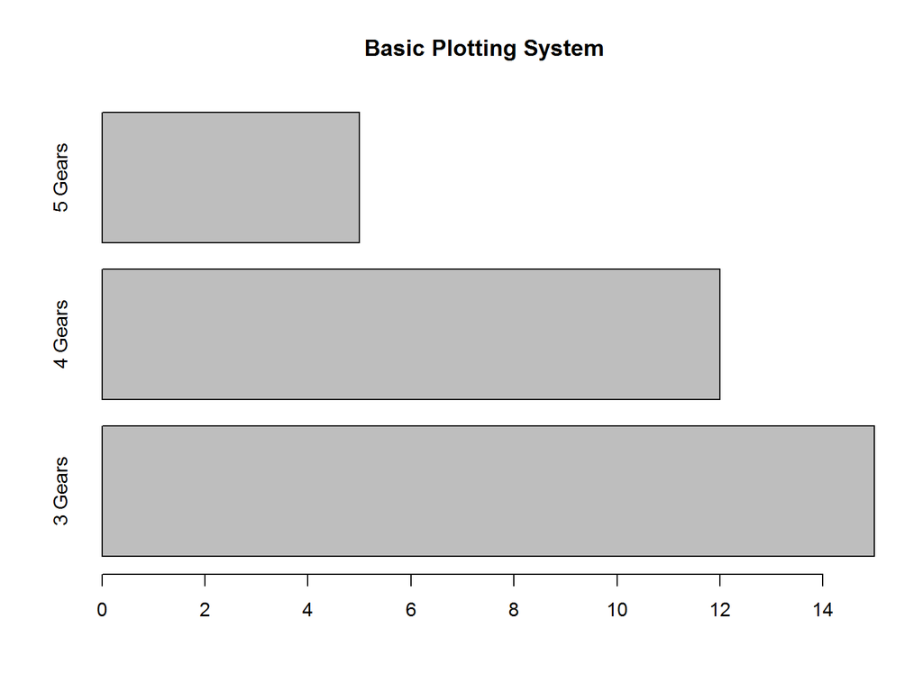

```r
counts <- table(mtcars$gear)
barplot(counts, main="Basic Plotting System", horiz=TRUE, names.arg=c("3 Gears", "4 Gears", "5 Gears"))
```

# ggplot2

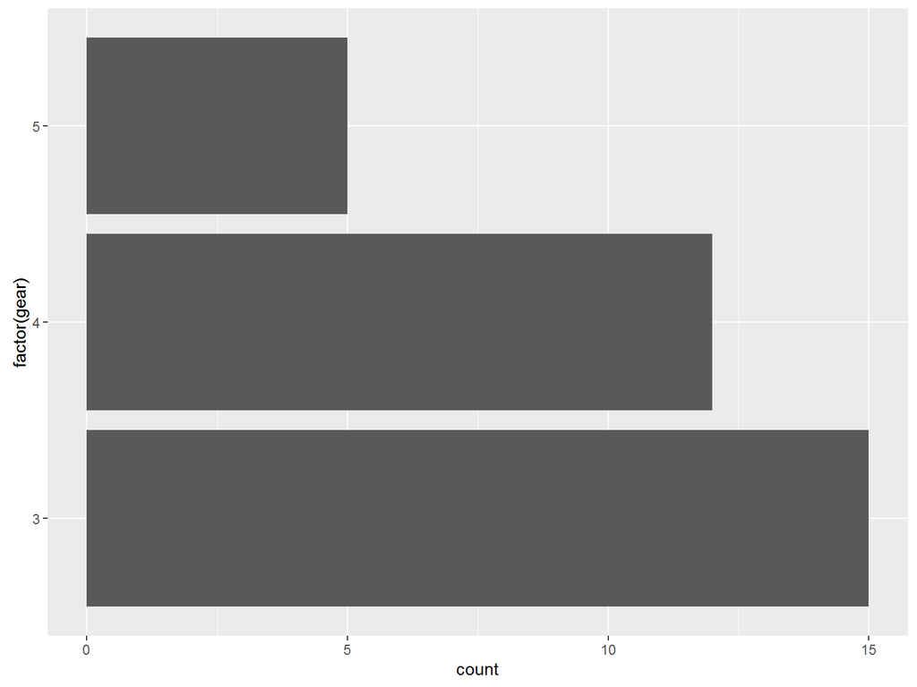

```r
library(ggplot2)
ggplot(mtcars, aes(factor(gear)))+geom_bar()+coord_flip()
```

# Plotly

```r
library(plotly)
countsDF <- data.frame(counts)
plot_ly(countsDF, x=Freq, y=Var1, type="bar", orientation="h")
```

[interactive chart not shown]

# Leaflet

```r
library(leaflet)
helloMap <- leaflet() %>%
  addTiles() %>% #把預設的地圖圖層加入
  addMarkers(lng=121.539366, lat=25.017326, popup="National Taiwan University")
helloMap
```

[interactive chart not shown]

# Shiny

- https://yaojenkuo.shinyapps.io/quakesTW/

# 建模型

```r
str(cars)
```

```
## 'data.frame':    50 obs. of  2 variables:
##  $ speed: num  4 4 7 7 8 9 10 10 10 11 ...
##  $ dist : num  2 10 4 22 16 10 18 26 34 17 ...
```

```r
scatterPlot <- plot_ly(cars, x=speed, y=dist, type="scatter", mode="markers", name="data points")
scatterPlot
```

[interactive chart not shown]

```r
fit <- lm(cars$dist~cars$speed)
scatterPlot <- add_trace(scatterPlot, y=fitted(fit), name="linear model", mode="lines")
scatterPlot
```

[interactive chart not shown]

# 做Presentation

- ioslides
- Slidy

# 講義

- [新手上路](https://github.com/yaojenkuo/RGettingStarted)
- [R語言玩資料視覺化](https://github.com/yaojenkuo/NTUTrainRL2)